# Hepatisis data analysis

## 4.9 Bagging (bootstrap aggregating)

### 4.9.1 Method

We can use both numeric and categorical data. Let’s specify model formula. We use all attributes and also model without variables that are useless from EDA (Age, Steroid, AlkPhosphate, Sgot).

Building random forest for different models and datasets (for different imputation methods and initial with missing values).

In the additional file, we can find basic information about the models.

Predicted posterior probabilities. Plot results where color - class. Since we have the same splits, we can use the same n, p, colors.

The results are not so good, because there are false predictions in all models and many probabilities in the middle.

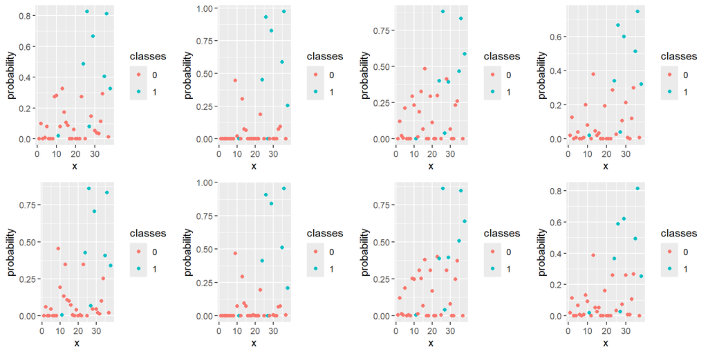

Let’s also plot histograms of predicted probabilities.

As we saw before, the results are not so good: many values are about 0, but also a lot of values are located in the middle between 0 and 1.

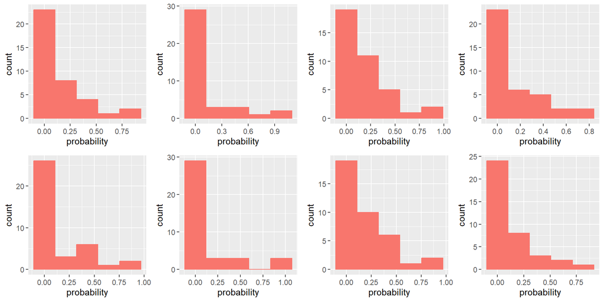

Predict class labels.

### 4.9.2 Comparison

| name | btree1 | btree2 | btree3 | btree4 | btree5 | btree6 | btree7 | btree8 |
| --- | --- | --- | --- | --- | --- | --- | --- | --- |
| Accuracy | 0.87 | 0.89 | 0.87 | 0.89 | 0.87 | 0.89 | 0.89 | 0.87 |
| Kappa | 0.49 | 0.61 | 0.49 | 0.61 | 0.49 | 0.61 | 0.61 | 0.49 |
| Sensitivity | 0.38 | 0.50 | 0.38 | 0.50 | 0.38 | 0.50 | 0.50 | 0.38 |
| Specificity | 1.00 | 1.00 | 1.00 | 1.00 | 1.00 | 1.00 | 1.00 | 1.00 |
| F1 | 0.55 | 0.67 | 0.55 | 0.67 | 0.55 | 0.67 | 0.67 | 0.55 |
| Balanced Accuracy | 0.69 | 0.75 | 0.69 | 0.75 | 0.69 | 0.75 | 0.75 | 0.69 |
| 10-fold CV error | 0.17 | 0.15 | 0.17 | 0.16 | 0.14 | 0.12 | 0.16 | 0.15 |
| Bootstrap error | 0.17 | 0.15 | 0.18 | 0.16 | 0.16 | 0.14 | 0.18 | 0.17 |

So, the best Bagging model when comparing the statistics:

- Accuracy: 2, 4, 6, 7
- Kappa: 2, 4, 6, 7
- Sensitivity: 2, 4, 6, 7
- Specificity: all
- F1: 2, 4, 6, 7
- Balanced Accuracy: 2, 4, 6, 7
- 10-fold CV: 6
- Bootstrap: 6

To sum up, the best Bagging model is the **6th** one: model without variables that are useless from EDA and bag tree imputing method

## 4.10 Boosting

### 4.10.1 Method

We can use both numeric and categorical data. Let’s specify model formula. We use all attributes and also model without variables that are useless from EDA (Age, Steroid, AlkPhosphate, Sgot).

Building random forest for different models and datasets (for different imputation methods).

In the additional file, we can find basic information about all models.

Predicted posterior probabilities. Plot results where color - class. Since we have the same splits, we can use the same n, p, colors.

The results are not so good, because there are false predictions in all models and many probabilities in the middle.

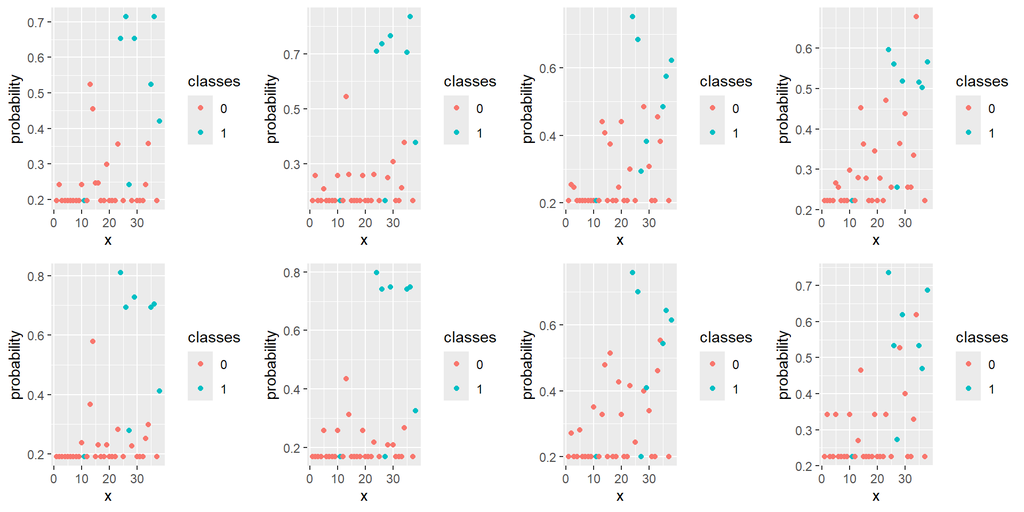

Let’s also plot histograms of predicted probabilities.

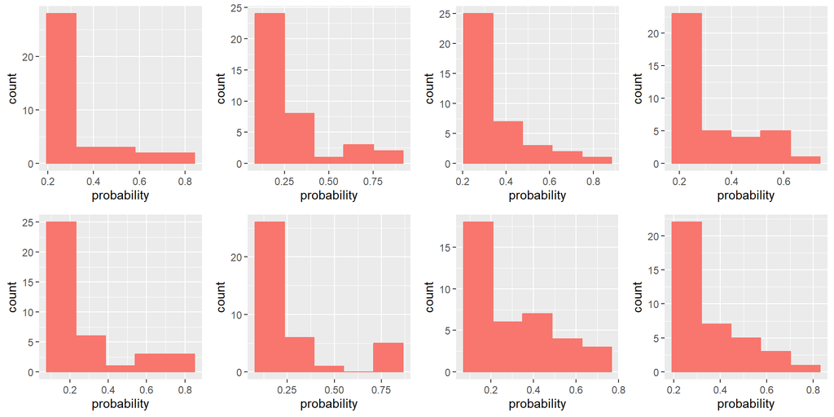

Predict class labels.

### 4.10.2 Comparison

| name | boost.1 | boost.2 | boost.3 | boost.4 | boost.5 | boost.6 | boost.7 | boost.8 |
| --- | --- | --- | --- | --- | --- | --- | --- | --- |
| Accuracy | 0.89 | 0.89 | 0.89 | 0.92 | 0.89 | 0.92 | 0.87 | 0.87 |
| Kappa | 0.65 | 0.65 | 0.61 | 0.75 | 0.65 | 0.72 | 0.59 | 0.59 |
| Sensitivity | 0.62 | 0.62 | 0.50 | 0.75 | 0.62 | 0.62 | 0.62 | 0.62 |
| Specificity | 0.97 | 0.97 | 1.00 | 0.97 | 0.97 | 1.00 | 0.93 | 0.93 |
| F1 | 0.71 | 0.71 | 0.67 | 0.80 | 0.71 | 0.77 | 0.67 | 0.67 |
| Balanced Accuracy | 0.80 | 0.80 | 0.75 | 0.86 | 0.80 | 0.81 | 0.78 | 0.78 |
| 10-fold CV error | 0.15 | 0.11 | 0.17 | 0.16 | 0.14 | 0.11 | 0.18 | 0.16 |
| Bootstrap error | 0.16 | 0.12 | 0.16 | 0.18 | 0.15 | 0.13 | 0.16 | 0.18 |

So, the best Boosting model when comparing the statistics:

- Accuracy: 4, 6
- Kappa: 4 -> 6
- Sensitivity: 4 -> 1, 2, 5, 6, 7, 8
- Specificity: 3, 6 -> 1, 2, 4, 5
- F1: 4 -> 6
- Balanced Accuracy: 4 -> 6
- 10-fold CV: 2, 6
- Bootstrap: 2 -> 6

To sum up, the best Boosting model is the **6th** one: model without variables that are useless from EDA and bag tree imputing method.

## 4.11 Random forest

### 4.11.1 Method

We can use both numeric and categorical data. Let’s specify model formula. We use all attributes and also model without variables that are useless from EDA (Age, Steroid, AlkPhosphate, Sgot). Also we need number of features.

Building random forest for different models, parameters (ntree - number of trees, mtry - number of randomly selected features), and datasets (for different imputation methods).

In the additional file, we can find basic information and classification error plot for the random forests.

Now, let’s create a plot that displays the importance of each predictor variable in the final model. The x-axis displays the average increase in node purity of the regression trees based on splitting on the various predictors displayed on the y-axis. From the plot we can see that Protime is the most important predictor variable.

In the additional file, we can see variable importance ranking for other random forest models. The results are different, but for each model, Protime is in the first place.

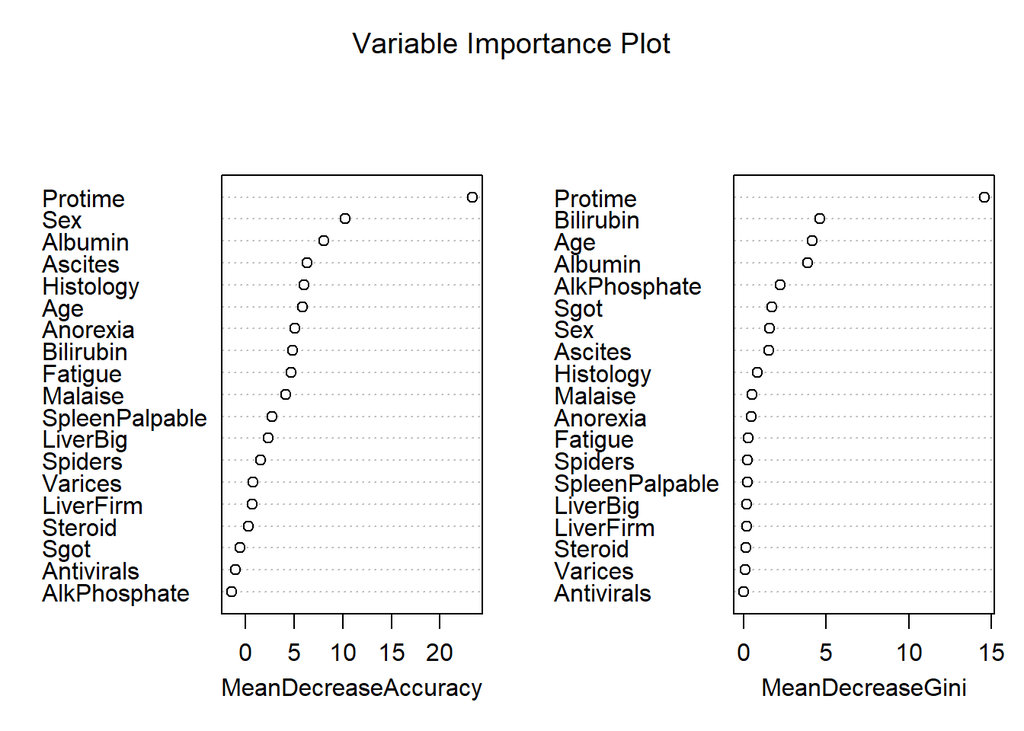

Predicted posterior probabilities. Plot results where color - class. Since we have the same splits, we can use the same n, p, colors.

The results are not so good, because there are false predictions in all models and many probabilities in the middle.

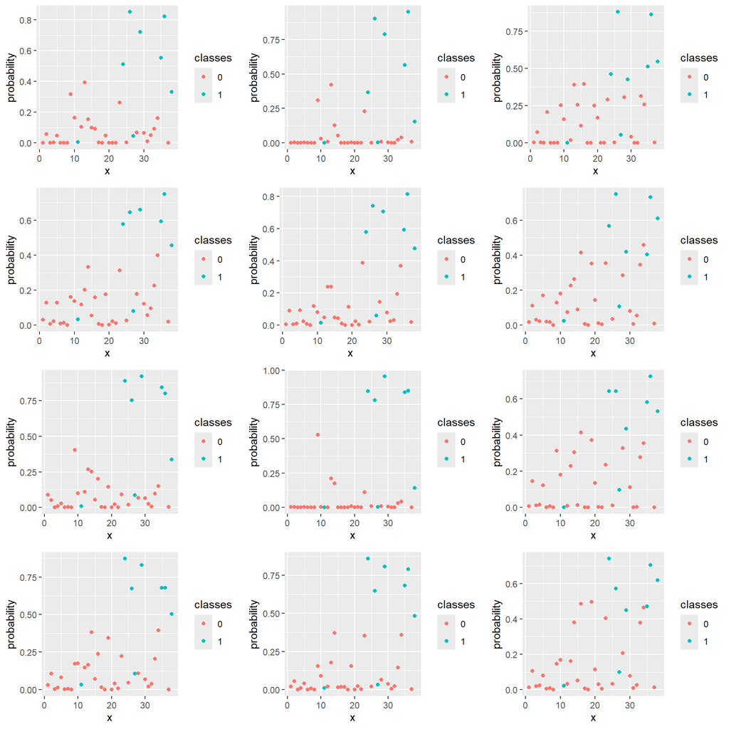

Let’s also plot histograms of predicted probabilities.

As we saw before, the results are not so good: many values are about 0, but also a lot of values are located in the middle between 0 and 1.

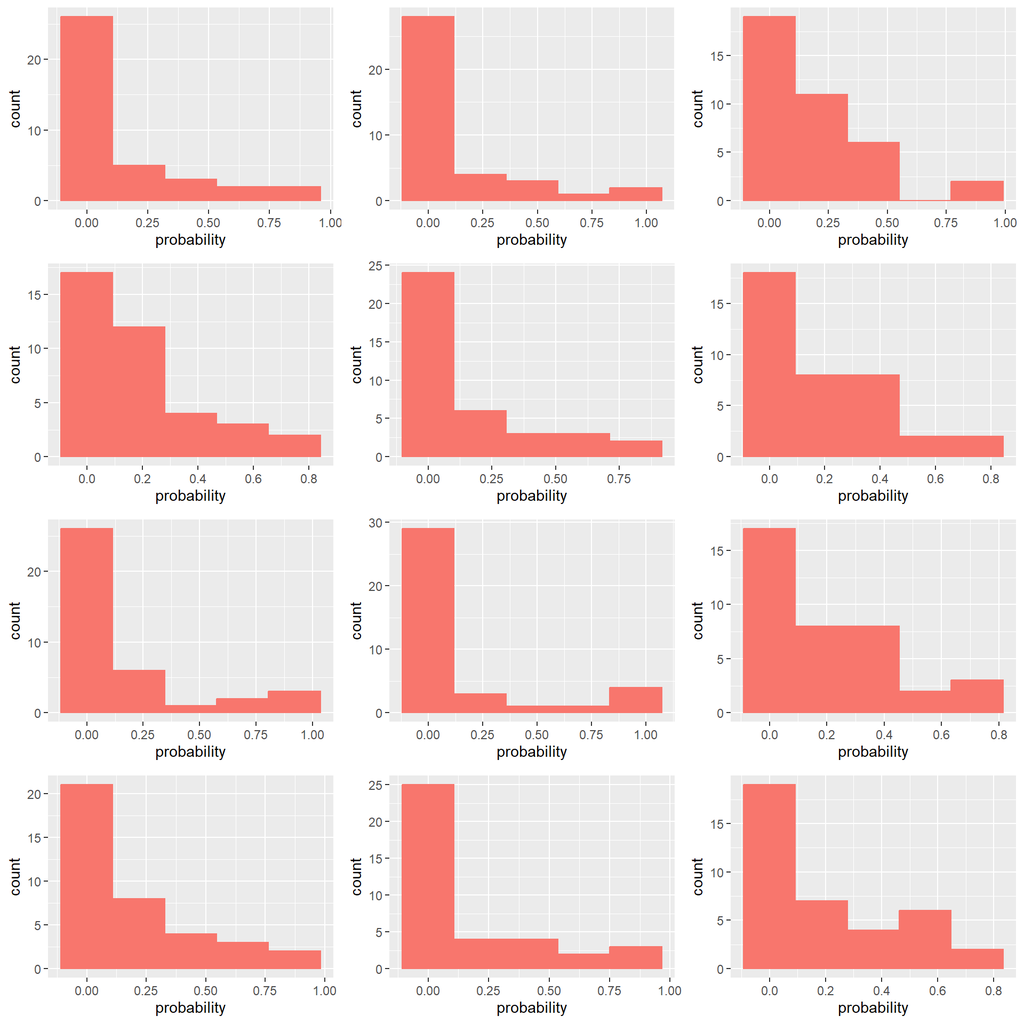

Predict class labels.

### 4.11.2 Comparison

| name | rf.1 | rf.2 | rf.3 | rf.4 | rf.5 | rf.6 | rf.7 | rf.8 | rf.9 | rf.10 | rf.11 | rf.12 |
| --- | --- | --- | --- | --- | --- | --- | --- | --- | --- | --- | --- | --- |
| Accuracy | 0.92 | 0.89 | 0.89 | 0.92 | 0.92 | 0.89 | 0.92 | 0.89 | 0.92 | 0.95 | 0.92 | 0.89 |
| Kappa | 0.72 | 0.61 | 0.61 | 0.72 | 0.72 | 0.61 | 0.72 | 0.65 | 0.72 | 0.83 | 0.72 | 0.61 |
| Sensitivity | 0.62 | 0.50 | 0.50 | 0.62 | 0.62 | 0.50 | 0.62 | 0.62 | 0.62 | 0.75 | 0.62 | 0.50 |
| Specificity | 1.00 | 1.00 | 1.00 | 1.00 | 1.00 | 1.00 | 1.00 | 0.97 | 1.00 | 1.00 | 1.00 | 1.00 |
| F1 | 0.77 | 0.67 | 0.67 | 0.77 | 0.77 | 0.67 | 0.77 | 0.71 | 0.77 | 0.86 | 0.77 | 0.67 |
| Balanced Accuracy | 0.81 | 0.75 | 0.75 | 0.81 | 0.81 | 0.75 | 0.81 | 0.80 | 0.81 | 0.88 | 0.81 | 0.75 |
| 10-fold CV error | 0.12 | 0.11 | 0.17 | 0.13 | 0.13 | 0.16 | 0.12 | 0.12 | 0.16 | 0.11 | 0.10 | 0.15 |
| Bootstrap error | 0.16 | 0.13 | 0.18 | 0.13 | 0.13 | 0.14 | 0.14 | 0.13 | 0.17 | 0.12 | 0.11 | 0.15 |

So, the best Random forest model when comparing the statistics:

- Accuracy: 10
- Kappa: 10
- Sensitivity: 10
- Specificity: 1, 2, 3, 4, 5, 6, 7, 9, 10, 11, 12
- F1: 10
- Balanced Accuracy: 10
- 10-fold CV: 11 -> 2, 10
- Bootstrap: 11 -> 10

To sum up, the best Random forest model is the **10th** one: model without variables that are useless from EDA, knn imputing method, and parameter mtry=sqrt(p).

## 4.12 Conclusions

The best models by methods:

| metric | Linear regression | LDA | QDA | Logistic regression |
| --- | --- | --- | --- | --- |
| Accuracy | 0.92 | 0.87 | 0.87 | 0.92 |
| Kappa | 0.75 | 0.65 | 0.62 | 0.75 |
| Sensitivity | 0.75 | 0.88 | 0.75 | 0.75 |
| Specificity | 0.97 | 0.87 | 0.90 | 0.97 |
| F1 | 0.80 | 0.74 | 0.71 | 0.80 |
| Balanced Accuracy | 0.86 | 0.87 | 0.82 | 0.86 |
| 10-fold CV error |  |  |  | 0.35 |
| Bootstrap error |  |  |  | 0.36 |

| KNN | Random Tree | Bagging Tree | Boosted Tree | Random Forest |
| --- | --- | --- | --- | --- |
| 0.79 | 0.92 | 0.89 | 0.92 | 0.95 |
| 0.50 | 0.72 | 0.61 | 0.72 | 0.83 |
| 0.88 | 0.62 | 0.50 | 0.62 | 0.75 |
| 0.77 | 1.00 | 1.00 | 1.00 | 1.00 |
| 0.64 | 0.77 | 0.67 | 0.77 | 0.86 |
| 0.82 | 0.81 | 0.75 | 0.81 | 0.88 |
|  | 0.14 | 0.12 | 0.11 | 0.11 |
|  | 0.15 | 0.14 | 0.13 | 0.12 |

So, the best model when comparing the statistics:

- Accuracy: Random forest
- Kappa: Random forest
- Sensitivity: KNN, LDA
- Specificity: Random tree, Bagging, Boosting, Random forest
- F1: Random forest
- Balanced Accuracy: Random forest
- 10-fold CV: Boosting, Random forest
- Bootstrap: Random forest

To sum up, the best model is **Random forest** model without variables that are useless from EDA, knn imputing method, and parameter mtry=sqrt(p).